# Demografia e homicídios no Brasil

Reprodução do artigo de (Cerqueira and Moura 2014).

## Introdução

- A demografia é um dos principais pontos de consenso na discussão a respeito das causas da criminalidade.
- O crescimento das cidades e adensamentos urbanos são importantes.
- Estruturas etárias e de gênero: o ciclo de vida na criminalidade the Thorneberry se inicia nos 12 anos de um jovem do sexo masculino, atinge seu ápice aos 18 anos e se esgota antes dos 30 anos.
- As mudanças geracionais, dadas pela proporção de jovens em relação ao total da população, são evidências mais controversas na literatura (ex: Zimring 2007 e Fox 2000).
- **No Brasil**: Mello e Schneider (2010) um aumento de 1,0% na população causa um aumnto de 4,5% na taxa de homicídios do estado de São Paulo.
- Oportunidades no mercado de trabalho se alteram conforme a proporção de jovens na população (Cerqueira e Moura, 2014).

## Demografia e homicídios em São Paulo nas décadas de 1980, 1990, 2000, 2010

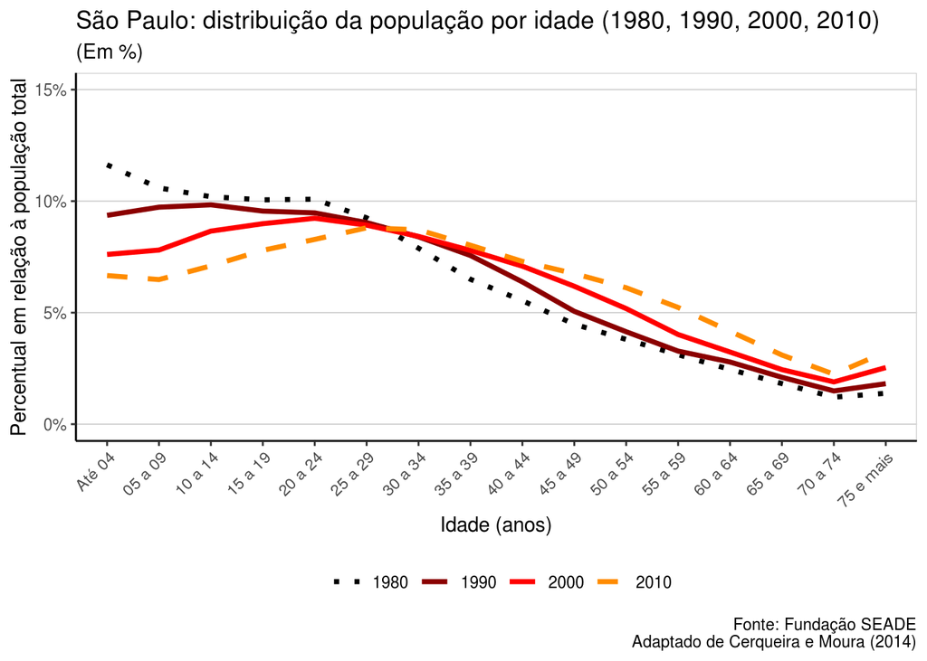

```r
library(tidyverse)
library(spcrimr)

pop_fxetaria_ano <- seade_completa %>%
  filter(ano <= 2017) %>%
  unnest() %>%
  select(ano, populacao, starts_with("populacao_de")) %>%
  rename(populacao_de_05_a_09_anos = populacao_de_5_a_9_anos,
         populacao_de_00_a_04_anos = populacao_de_0_a_4_anos) %>%
  select(-populacao_de_7_a_10_anos,
         -populacao_de_4_a_6_anos,
         -populacao_de_0_a_3_anos,
         -populacao_de_11_a_14_anos,
         -populacao_de_15_a_17_anos,
         -populacao_de_18_a_19_anos) %>%
  select(ano, populacao, populacao_de_00_a_04_anos,
         populacao_de_05_a_09_anos,
         everything())  %>%
  group_by(ano) %>%
  summarise_all(~ sum(., na.rm = T))

# labels mais legíveis
nm_faixas_etarias <- pop_fxetaria_ano %>%
  names() %>%
  .[-c(1:2)] %>%
  str_remove_all("populacao_de_") %>%
  str_remove_all("_anos") %>%
  str_replace_all("_", " ") %>%
  str_replace_all("00 a", "Até")

names(pop_fxetaria_ano)[-c(1:2)] <- nm_faixas_etarias

# agrupa -----------------------------------------------------------------------
soma_fxetarias_por_decada <- function(d){

  decades <- c(1980, 1990, 2000, 2010)
  d$decada <- decades[findInterval(d$ano, decades)]

  d %>%
    select(-ano) %>%
    group_by(decada) %>%
    summarise_all(~ sum(.))

}

pop_fxetaria_decada <- pop_fxetaria_ano %>% soma_fxetarias_por_decada()
pop_fxetaria_decada$variavel <- "populacao"


pop_fxetaria_decada %>%
  # percentual da população por faixa etária ----------------------------
  mutate_at(vars(matches(" ")), ~ ./ populacao) %>%
  select(-populacao, -variavel) %>%
  gather(key = idade, value = proporcao, -decada, factor_key = TRUE) %>%
  mutate(decada = factor(decada)) %>%
  filter(idade != "populacao") %>%
  # ggplot --------------------------------------------------------------
  ggplot(aes(x = idade,
             y = proporcao,
             colour = decada,
             group = decada)) +
  geom_line(aes(linetype = decada), size = 1.3) +
  scale_linetype_manual(values = c("dotted", "solid", "solid", "dashed")) +
  scale_color_manual(values = c("black", "darkred", "red", "darkorange")) +
  labs(title = "São Paulo: distribuição da população por idade (1980, 1990, 2000, 2010)",
       subtitlee = "(Em %)",
       y = "Percentual em relação à população total",
       x = "Idade (anos)",
       caption = "Fonte: Fundação SEADE\nAdaptado de Cerqueira e Moura (2014)") +
  theme_classic() +
  theme(legend.position = "bottom",
        axis.text.x = element_text(angle = 45, hjust=1, vjust=1),
        legend.title = element_blank(),
        panel.border = element_rect(fill = NA, color = "lightgrey"),
        panel.grid.major.y = element_line(color = "lightgrey")) +
  scale_y_continuous(limits = c(0, .15),
                     breaks = seq(0, .15, 0.05),
                     labels = paste0(seq(0, 15, 5), "%"))
```

## Taxa de homicídios

O problema da obtenção das taxas de homicídio no Brasil é conhecido no debate na área. O estado de São Paulo possui uma das bases mais completas (que está disponível no pacote `spcrimr`), entretanto essa base inicia-se somente nos anos 2000.

A alternativa utilizada pelos autores é a base de dados do Sistema de Informações sobre Mortalidade (SIM/Datasus). Os dados são obtidos em conformidade com a revisão vigente do Código Internacional de Doenças, que atualmente está na 10° revisão. Até 1995 o procedimento de coleta de dados seguia a 9° revisão.

### Revisões do Código Internacional de Doenças (CID)

- *CID-9*:
  - Até 1995 - 9° Revisão - códigos: E960 até E977 (Cerqueira 2014)
- *CID-10*:
  - 1996 até 2018 - 10° Revisão - códigos: X85 a Y09 (Cerqueira et al. 2018)

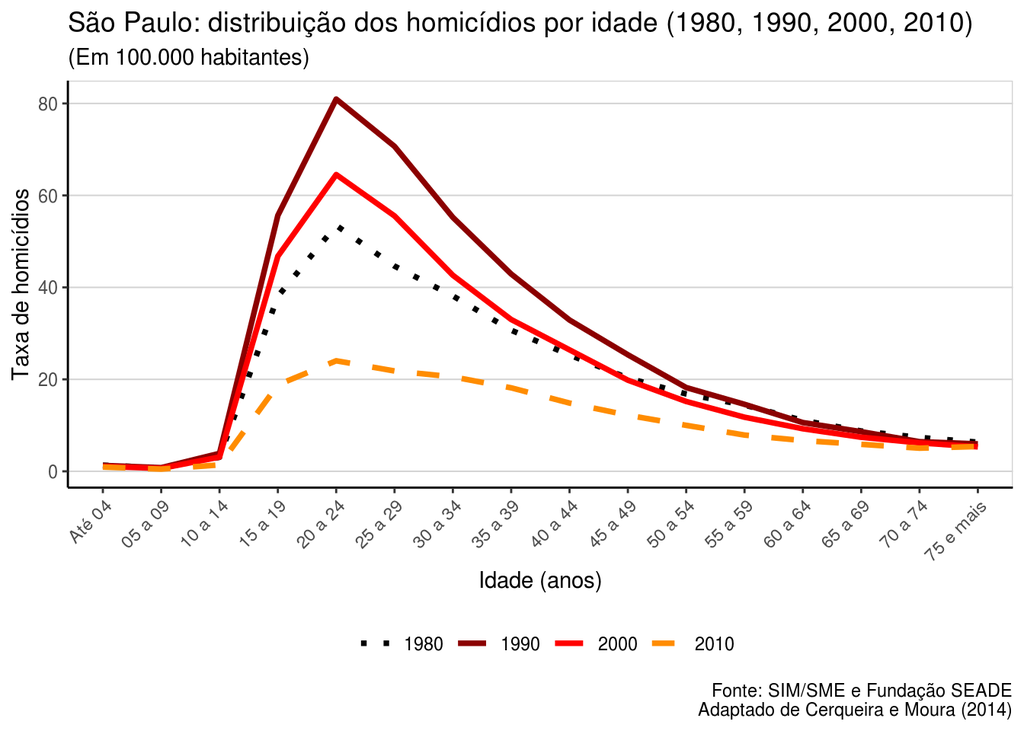

```r
# lendo dados do datasus -------------------------------------------------------

cid <- function(arq, skip, inicio, fim){

  #mydir <- "~/[documentos]Raul/R[scripts]/analises/Projeto/data/"
  mydir <- "~/Projeto/data/"

  # carrega cid9.csv
  cid <- read_delim(
    file    = paste0(mydir, arq),
    delim   = ";",
    locale  = locale(encoding = "latin1"),
    trim_ws = TRUE,
    skip    =  skip,
    escape_double = FALSE)

  # subset
  cid <- cid[1:length(seq(inicio, fim)), -ncol(cid)]

  # transformações básicas
  cid <- cid %>%
    janitor::clean_names() %>%
    select(- ano_do_obito) %>%
    mutate_all(~ str_replace_all(., "-", "NA")) %>%
    mutate_if(is.character, as.integer)

  #
  ate5 <- cid %>% select(x0_a_6_dias:x1_a_4_anos) %>% rowSums(na.rm = T)
  olds <- cid %>% select(x75_a_79_anos:x80_anos_e_mais) %>% rowSums(na.rm = T)

  #
  cid <- cid %>%
    select(x5_a_9_anos:x70_a_74_anos) %>%
    mutate(ate5 = ate5,
           olds = olds,
           ano = seq(inicio, fim)) %>%
    select(ano, ate5, everything(), olds)

  return(cid)

}

homic_fxetaria_ano <- bind_rows(cid("cid9.csv", skip = 6, 1980, 1995),
                                cid("cid10.csv", skip = 5, 1996, 2017))

names(homic_fxetaria_ano)[-1] <- nm_faixas_etarias

homic_fxetaria_decada <- homic_fxetaria_ano %>% soma_fxetarias_por_decada()
homic_fxetaria_decada$variavel <- "homicidio"

txhom_fxetaria_decada <- pop_fxetaria_decada %>%
  select(-populacao) %>%
  bind_rows(., homic_fxetaria_decada) %>%
  gather(faixa_etaria, value, -decada, -variavel, factor_key = T) %>%
  spread(variavel, value)  %>%
  mutate(decada = factor(decada))

txhom_fxetaria_decada %>%
  ggplot(aes(x = faixa_etaria,
             y = homicidio / populacao * 100000,
             colour = decada,
             group = decada)) +
  geom_line(aes(linetype = decada), size=1.3) +
  scale_linetype_manual(values=c("dotted", "solid", "solid", "dashed")) +
  scale_color_manual(values=c("black", "darkred", "red", "darkorange")) +
  labs(title = "São Paulo: distribuição dos homicídios por idade (1980, 1990, 2000, 2010)",
       subtitlee = "(Em 100.000 habitantes)",
       y = "Taxa de homicídios",
       x = "Idade (anos)",
       caption = "Fonte: SIM/SME e Fundação SEADE\nAdaptado de Cerqueira e Moura (2014)") +
  theme_classic() +
  theme(legend.position="bottom",
        axis.text.x = element_text(angle = 45, hjust=1, vjust=1),
        legend.title = element_blank(),
        panel.border = element_rect(fill=NA, color = "lightgrey"),
        panel.grid.major.y = element_line(color="lightgrey"))
```

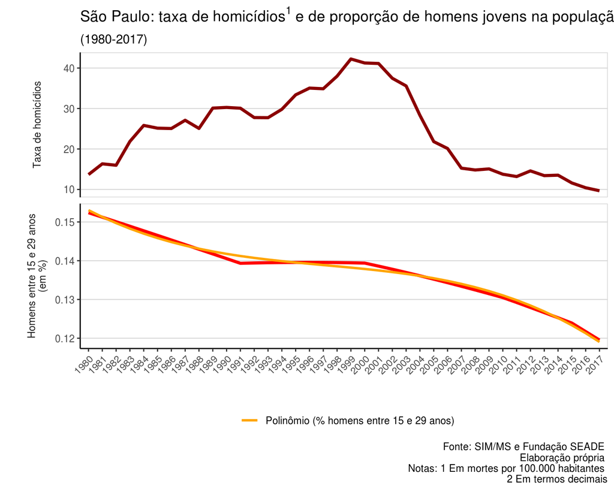

```r
homic_jov1529_ano <- homic_fxetaria_ano %>%
  transmute(ano = ano,
            homic_jov1529_ano = `15 a 19` + `20 a 24` + `25 a 29`,
            homic_total = rowSums(homic_fxetaria_ano[ ,2:17], na.rm=T))

pop_jov1529_ano <- seade_completa %>%
  unnest() %>%
  group_by(ano) %>%
  summarise(populacao = sum(populacao, na.rm=T),
            pop_jov1529_ano = sum(populacao_masculina_de_15_a_19_anos,
                                  populacao_masculina_de_20_a_24_anos,
                                  populacao_masculina_de_25_a_29_anos,
                                  na.rm=T))

txhomic_jov1529_ano <- inner_join(pop_jov1529_ano, homic_jov1529_ano, by = "ano")


d <- txhomic_jov1529_ano %>%
  transmute(ano = ano,
            jovens1529 = pop_jov1529_ano / populacao,
            homic = homic_total / populacao * 100000) %>%
  gather(key = variavel, value = proporcao, -ano)

d %>%
  ggplot(aes(x = ano,
             y = proporcao,
             group = variavel,
             colour = variavel)) +
  geom_line(size=1.3, show.legend = F) +
  facet_wrap(~ variavel,
             ncol = 1,
             scales = "free_y",
             strip.position = "left",
             labeller = as_labeller(c(jovens1529 = "Homens entre 15 e 29 anos\n(em %)",
                                      homic = "Taxa de homicídios"))) +
  geom_smooth(data = filter(d, variavel == "jovens1529"),
              color = "orange",
              aes(fill="Polinômio (% homens entre 15 e 29 anos)"),
              method = "lm", formula = y ~ splines::bs(x, 3), se = FALSE) +
  scale_color_manual(values=c("darkred", "red")) +
  theme_classic() +
  theme(legend.position = "bottom",
        axis.text.x = element_text(angle = 45, hjust=1, vjust=1),
        legend.title = element_blank(),
        panel.border = element_rect(fill=NA, color = "lightgrey"),
        panel.grid.major.y = element_line(color="lightgrey"),
        strip.placement = "outside",
        strip.background = element_blank()) +
  scale_x_discrete(limits = seq(1980, 2017),
                   breaks = seq(1980, 2017),
                   labels = seq(1980, 2017)) +
  labs(x="", y="",
       title = expression("São Paulo: taxa de" ~  homicídios^1 ~ "e de proporção de homens jovens na" ~ população^2),
       subtitle = "(1980-2017)",
       caption= "Fonte: SIM/MS e Fundação SEADE \n Elaboração própria \n Notas: 1 Em mortes por 100.000 habitantes \n 2 Em termos decimais")
```

Destaques:

- Aumento na taxa de homicídios até os anos 2000 em São Paulo, seguido de queda contínua e abrupta.
- No Brasil, esse aumento vai até 2006 Cerqueira (2014).
- Tanto em Cerqueira (2014) quanto neste caso, os jovens são profundamente afetados pela violência.

## A relação empírica entre demografia e homicídios com base em dois métodos analíticos

### Metodologia *shift-share*

> “(…) permite decompor a variação da taxa de homicídio em dois componentes, conhecidos como efeitos de **nível** e de **composição**. O cálculo subjacente se inicia com o reconhecimento de que a taxa de homicídios de um país em um dado ano, pode ser escrita como a média ponderada das taxas de homicídio para cada idade, em que o ponderador refere-se à parcela da população naquela idade, conforme descrito na equação (…) (p. 362)”.

$$txhom_{t} = \sum_{j = 1}^{n} txhom_{jt} \frac{pop_{jt}}{pop_{t}}$$

- $txhom_{jt}$ é a taxa de homicídios por 100 mil habitantes do grupo etário $j$ no ano $t$.
- $pop_{jt}$ é a população do grupo etário $j$ no ano $t$
- $pop_{t}$ é a população no ano $t$

```r
pop_fxetaria_ano$variavel <- "pop_jt"
homic_fxetaria_ano$variavel <- "hom_jt"

txhom_fxetaria_ano <- pop_fxetaria_ano %>%
  select(-populacao) %>%
  bind_rows(., homic_fxetaria_ano) %>%
  gather(j, value, -ano, -variavel, factor_key = T) %>%
  spread(variavel, value)  %>%
  rename(t = ano) %>%
  arrange(j)

txhom_fxetaria_ano %>%
  group_by(t) %>%
  mutate(
    txhom_jt = hom_jt / pop_jt * 100000,
    pop_t = sum(pop_jt),
    txhom_t = sum(txhom_jt * (pop_jt / pop_t))
  ) -> txhom_fxetaria_ano
```

A equação abaixo mostra a variação da taxa de homicídio entre dois períodos.

$$txhom_{t} - txhom_{t-1} = \sum_{j = 1}^{n} txhom_{jt} \frac{pop_{jt}}{pop_{t}} - \sum_{j = 1}^{n} txhom_{jt-1} \frac{pop_{jt-1}}{pop_{t-1}}$$
Desenvolvendo a equação, Podemos decompor essa variação em duas partes:

$$txhom_{t} - txhom_{t-1} = (\sum_{j = 1}^{n}(txhom_{jt} - txhom_{jt-1})\overline{(\frac{pop_{jt}}{pop_{t}})}) + (\sum_{j=1}^{n}(\frac{pop_{jt}}{pop_{t}} - \frac{pop_{jt-1}}{pop_{t}}) \overline{txhom_{j}})$$

- **Efeito de nível**: parte que mede o crescimento da taxa de homicídio devidos a mudanças **não** demográficas:
  - $(\sum_{j = 1}^{n}(txhom_{jt} - txhom_{jt-1})\overline{(\frac{pop_{jt}}{pop_{t}})})$
- **Efeito Composição**: parte que mede o crescimento da taxa de homicídio devidos a mudanças **exclusivamente** demográficas:
  - $(\sum_{j=1}^{n}(\frac{pop_{jt}}{pop_{t}} - \frac{pop_{jt-1}}{pop_{t}}) \overline{txhom_{j}})$

```r
txhom_fxetaria_ano %>%
  filter(t %in% c(1980, 1990, 2000, 2017)) %>%
  group_by(j) %>%
  mutate(
    txhom_jt0 = lag(txhom_jt, 1),
    lag_txhom = txhom_jt - txhom_jt0)
```

```
#> # A tibble: 64 x 9
#> # Groups:   j [16]
#>        t j       hom_jt pop_jt txhom_jt   pop_t txhom_t txhom_jt0 lag_txhom
#>    <int> <fct>    <dbl>  <dbl>    <dbl>   <dbl>   <dbl>     <dbl>     <dbl>
#>  1  1980 Até 04      39 3.26e6    1.20   2.50e7   13.7     NA      NA
#>  2  1990 Até 04      39 3.11e6    1.25   3.08e7   30.3      1.20    0.0547
#>  3  2000 Até 04      40 3.19e6    1.26   3.70e7   41.3      1.25    0.00281
#>  4  2017 Até 04      18 2.90e6    0.620  4.37e7    9.68     1.26   -0.635
#>  5  1980 05 a 09     14 2.63e6    0.532  2.50e7   13.7     NA      NA
#>  6  1990 05 a 09     32 3.26e6    0.980  3.08e7   30.3      0.532   0.449
#>  7  2000 05 a 09     26 3.16e6    0.822  3.70e7   41.3      0.980  -0.158
#>  8  2017 05 a 09     12 2.76e6    0.434  4.37e7    9.68     0.822  -0.388
#>  9  1980 10 a 14     40 2.51e6    1.59   2.50e7   13.7     NA      NA
#> 10  1990 10 a 14    119 3.17e6    3.75   3.08e7   30.3      1.59    2.16
#> # … with 54 more rows
```

## Referências

Cerqueira, Daniel. 2014. *Causas E Consequências Do Crime No Brasil*. Banco Nacional de Desenvolvimento Econômico e Social.

Cerqueira, Daniel, Renato Sergio de Lima, Samira Bueno, Cristina Neme, Helder Ferreira, Danilo Coelho, Paloma Palmieri Alves, et al. 2018. “Atlas Da Violência 2018.” Instituto de Pesquisa Econômica Aplicada (IPEA).

Cerqueira, Daniel, and Rodrigo Leandro Moura. 2014. “Demografia E Homicı'dios No Brasil.” *Novo Regime Demográfico: Uma Nova Relação Entre População E Desenvolvimento. Rio de Janeiro: Ipea*.